# Lecture 3 Code

Alex Hoagland

2024-02-07

## Simple hypothesis test: One mean

Let’s start with defining the test procedure for a simple mean. We will use the Wooldridge `wagepan` data set.

```r
# Load the Wooldridge wag2 data
mydata <- wooldridge::wagepan

summary(mydata) # What are we looking at?
```

```
##        nr             year          agric             black
##  Min.   :   13   Min.   :1980   Min.   :0.00000   Min.   :0.0000
##  1st Qu.: 2329   1st Qu.:1982   1st Qu.:0.00000   1st Qu.:0.0000
##  Median : 4569   Median :1984   Median :0.00000   Median :0.0000
##  Mean   : 5262   Mean   :1984   Mean   :0.03211   Mean   :0.1156
##  3rd Qu.: 8406   3rd Qu.:1985   3rd Qu.:0.00000   3rd Qu.:0.0000
##  Max.   :12548   Max.   :1987   Max.   :1.00000   Max.   :1.0000
##       bus             construc          ent              exper
##  Min.   :0.00000   Min.   :0.000   Min.   :0.00000   Min.   : 0.000
##  1st Qu.:0.00000   1st Qu.:0.000   1st Qu.:0.00000   1st Qu.: 4.000
##  Median :0.00000   Median :0.000   Median :0.00000   Median : 6.000
##  Mean   :0.07592   Mean   :0.075   Mean   :0.01514   Mean   : 6.515
##  3rd Qu.:0.00000   3rd Qu.:0.000   3rd Qu.:0.00000   3rd Qu.: 9.000
##  Max.   :1.00000   Max.   :1.000   Max.   :1.00000   Max.   :18.000
##       fin               hisp          poorhlth           hours
##  Min.   :0.00000   Min.   :0.000   Min.   :0.00000   Min.   : 120
##  1st Qu.:0.00000   1st Qu.:0.000   1st Qu.:0.00000   1st Qu.:2040
##  Median :0.00000   Median :0.000   Median :0.00000   Median :2080
##  Mean   :0.03693   Mean   :0.156   Mean   :0.01697   Mean   :2191
##  3rd Qu.:0.00000   3rd Qu.:0.000   3rd Qu.:0.00000   3rd Qu.:2414
##  Max.   :1.00000   Max.   :1.000   Max.   :1.00000   Max.   :4992
##      manuf           married           min            nrthcen
##  Min.   :0.0000   Min.   :0.000   Min.   :0.0000   Min.   :0.0000
##  1st Qu.:0.0000   1st Qu.:0.000   1st Qu.:0.0000   1st Qu.:0.0000
##  Median :0.0000   Median :0.000   Median :0.0000   Median :0.0000
##  Mean   :0.2823   Mean   :0.439   Mean   :0.0156   Mean   :0.2578
##  3rd Qu.:1.0000   3rd Qu.:1.000   3rd Qu.:0.0000   3rd Qu.:1.0000
##  Max.   :1.0000   Max.   :1.000   Max.   :1.0000   Max.   :1.0000
##     nrtheast           occ1             occ2              occ3
##  Min.   :0.0000   Min.   :0.0000   Min.   :0.00000   Min.   :0.00000
##  1st Qu.:0.0000   1st Qu.:0.0000   1st Qu.:0.00000   1st Qu.:0.00000
##  Median :0.0000   Median :0.0000   Median :0.00000   Median :0.00000
##  Mean   :0.1901   Mean   :0.1039   Mean   :0.09151   Mean   :0.05344
##  3rd Qu.:0.0000   3rd Qu.:0.0000   3rd Qu.:0.00000   3rd Qu.:0.00000
##  Max.   :1.0000   Max.   :1.0000   Max.   :1.00000   Max.   :1.00000
##       occ4             occ5             occ6             occ7
##  Min.   :0.0000   Min.   :0.0000   Min.   :0.0000   Min.   :0.00000
##  1st Qu.:0.0000   1st Qu.:0.0000   1st Qu.:0.0000   1st Qu.:0.00000
##  Median :0.0000   Median :0.0000   Median :0.0000   Median :0.00000
##  Mean   :0.1115   Mean   :0.2142   Mean   :0.2021   Mean   :0.09197
```

[output cut: 22 more lines]

```
##  Max.   :1.0000   Max.   :1.0000   Max.   :1.000   Max.   : 4.052
##       d81             d82             d83             d84
##  Min.   :0.000   Min.   :0.000   Min.   :0.000   Min.   :0.000
##  1st Qu.:0.000   1st Qu.:0.000   1st Qu.:0.000   1st Qu.:0.000
##  Median :0.000   Median :0.000   Median :0.000   Median :0.000
##  Mean   :0.125   Mean   :0.125   Mean   :0.125   Mean   :0.125
##  3rd Qu.:0.000   3rd Qu.:0.000   3rd Qu.:0.000   3rd Qu.:0.000
##  Max.   :1.000   Max.   :1.000   Max.   :1.000   Max.   :1.000
##       d85             d86             d87           expersq
##  Min.   :0.000   Min.   :0.000   Min.   :0.000   Min.   :  0.00
##  1st Qu.:0.000   1st Qu.:0.000   1st Qu.:0.000   1st Qu.: 16.00
##  Median :0.000   Median :0.000   Median :0.000   Median : 36.00
##  Mean   :0.125   Mean   :0.125   Mean   :0.125   Mean   : 50.42
##  3rd Qu.:0.000   3rd Qu.:0.000   3rd Qu.:0.000   3rd Qu.: 81.00
##  Max.   :1.000   Max.   :1.000   Max.   :1.000   Max.   :324.00
```

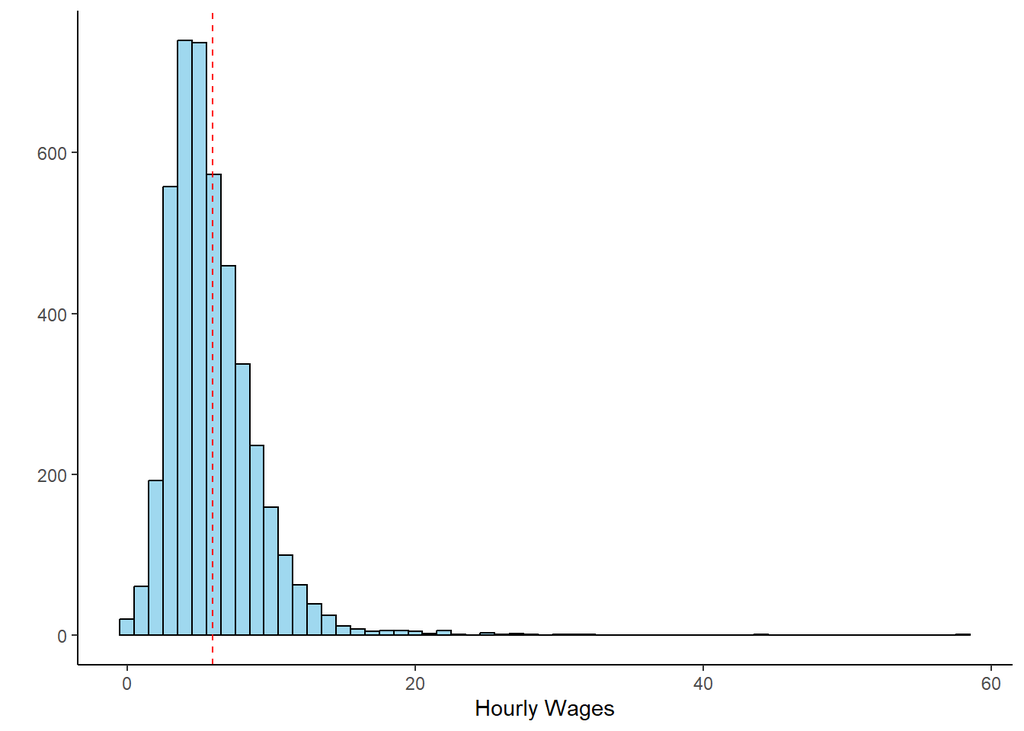

```r
# Let's describe wages
mydata %>% mutate(wage = exp(lwage)) %>% # convert to dollars
  ggplot() + geom_histogram(aes(wage),
                            binwidth=1,fill='skyblue',color='black',alpha=.8) +
  theme_classic() +
  geom_vline(xintercept=5.9192, color="red", linetype="dashed") +
    # line for average wage in sample
  labs(x="Hourly Wages", y="") # plot the distribution of wages
```

```r
# What do we see here?

# Let's test the hypothesis that the average wage is $7.77 (average hourly wage in USD, 1985)
  # First, what's the null here? Why did we choose it?
  # What's the test statistic?
  mean(exp(mydata$lwage)) # average wage is $5.92 in sample
```

```
## [1] 5.919175
```

```r
  sd(exp(mydata$lwage)) # SD is 3.20
```

```
## [1] 3.202225
```

```r
  (5.92-7.77)/(3.20/sqrt(4360)) # t-statistic (how do we interpret this?)
```

```
## [1] -38.17376
```

```r
t.test(exp(mydata$lwage), mu=7.77) # What do we think? Ignore p-value for now
```

```
##
##  One Sample t-test
##
## data:  exp(mydata$lwage)
## t = -38.164, df = 4359, p-value < 2.2e-16
## alternative hypothesis: true mean is not equal to 7.77
## 95 percent confidence interval:
##  5.824098 6.014253
## sample estimates:
## mean of x
##  5.919175
```

```r
  # What's the conclusion? How do we interpret our test?
```

## Testing difference in means

Okay, now suppose we want to test difference in wages across groups. Let’s look at two comparisons: black/non-black and health status.

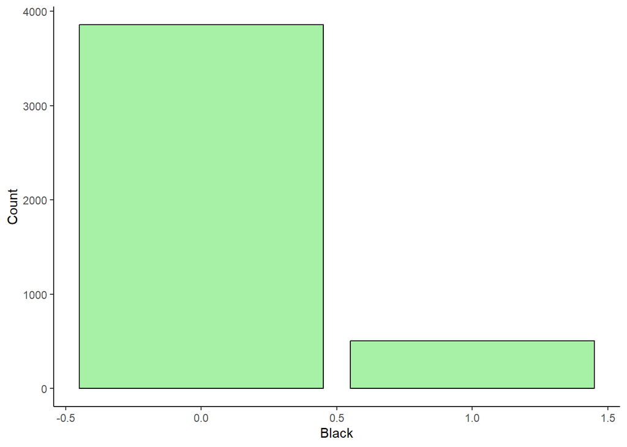

```r
# First, let's compare black/non-black.
# Make a bar chart showing size of black and non-black groups in mydata
mydata %>% ggplot() + geom_bar(aes(black), fill='palegreen2',color='black',alpha=.8) +
  theme_classic() + labs(x="Black", y="Count")
```

```r
summary(mydata$black) # What do we make of this?
```

```
##    Min. 1st Qu.  Median    Mean 3rd Qu.    Max.
##  0.0000  0.0000  0.0000  0.1156  0.0000  1.0000
```

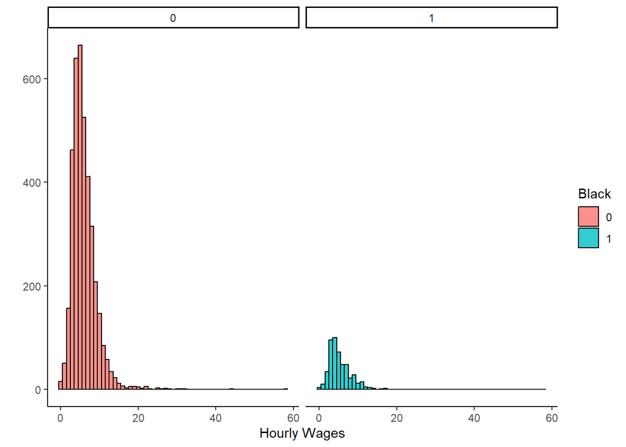

```r
# Now make a two-way histogram for exp(lwage) across black and non-black in mydata
mydata %>% mutate(wage = exp(lwage)) %>% ggplot() + geom_histogram(aes(wage,fill=as.factor(black)),                           binwidth=1,position="dodge",color='black',alpha=.8) +
  theme_classic() + labs(x="Hourly Wages", y="",fill="Black") + facet_wrap(~black) # plot the distribution of wages
```

```r
# Now let's test the difference in wages across black and non-black
  # First, what's the null here? Why did we choose it?
  # What's the test statistic?
  mean(exp(mydata[which(mydata$black==0),]$lwage)) # 6.00
```

```
## [1] 6.004713
```

```r
  mean(exp(mydata[which(mydata$black==1),]$lwage)) # 5.26
```

```
## [1] 5.264744
```

```r
  sd(exp(mydata[which(mydata$black==0),]$lwage)) # SD is 3.25
```

```
## [1] 3.250162
```

```r
  sd(exp(mydata[which(mydata$black==1),]$lwage)) # SD is 2.72
```

```
## [1] 2.723762
```

```r
  (6.00-5.26)/(sqrt((3.25^2/3856)+(2.72^2/504))) # t-statistic (how do we interpret this?)
```

```
## [1] 5.606929
```

```r
t.test(exp(mydata$lwage) ~ mydata$black) # What do we think?
```

```
##
##  Welch Two Sample t-test
##
## data:  exp(mydata$lwage) by mydata$black
## t = 5.6001, df = 704.46, p-value = 3.072e-08
## alternative hypothesis: true difference in means between group 0 and group 1 is not equal to 0
## 95 percent confidence interval:
##  0.4805443 0.9993931
## sample estimates:
## mean in group 0 mean in group 1
##        6.004713        5.264744
```

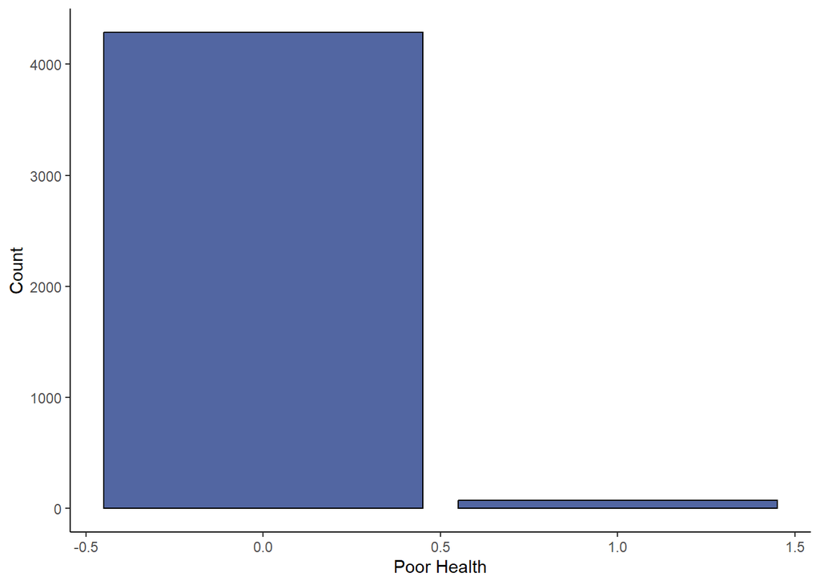

```r
# What if we do the same thing for poor health instead of black?
# Make a bar chart showing size of groups
mydata %>% ggplot() + geom_bar(aes(poorhlth), fill='royalblue4',color='black',alpha=.8) +
  theme_classic() + labs(x="Poor Health", y="Count")
```

```r
summary(mydata$poorhlth) # What do we make of this?
```

```
##    Min. 1st Qu.  Median    Mean 3rd Qu.    Max.
## 0.00000 0.00000 0.00000 0.01697 0.00000 1.00000
```

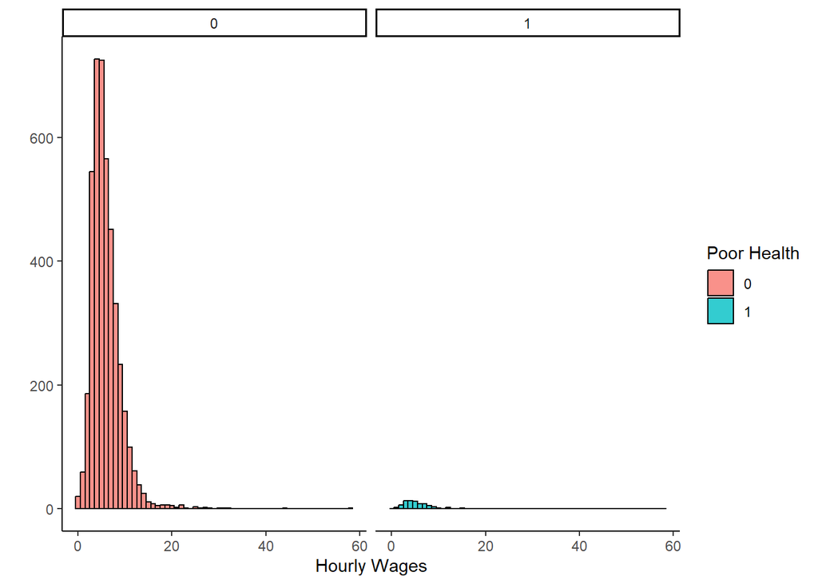

```r
# Now make a two-way histogram for exp(lwage) across groups
mydata %>% mutate(wage = exp(lwage)) %>% ggplot() + geom_histogram(aes(wage,fill=as.factor(poorhlth)),                           binwidth=1,position="dodge",color='black',alpha=.8) +
  theme_classic() + labs(x="Hourly Wages", y="",fill="Poor Health") + facet_wrap(~poorhlth) # plot the distribution of wages
```

```r
# Now let's test the difference in wages across groups
  # First, what's the null here? Why did we choose it?
  # What's the test statistic?
  mean(exp(mydata[which(mydata$poorhlth==0),]$lwage)) # 5.93
```

```
## [1] 5.931479
```

```r
  mean(exp(mydata[which(mydata$poorhlth==1),]$lwage)) # 5.21
```

```
## [1] 5.206573
```

```r
  sd(exp(mydata[which(mydata$poorhlth==0),]$lwage)) # SD is 3.21
```

```
## [1] 3.210519
```

```r
  sd(exp(mydata[which(mydata$poorhlth==1),]$lwage)) # SD is 2.60
```

```
## [1] 2.597872
```

```r
  (5.93-5.21)/(sqrt((3.21^2/(4360-74))+(2.60^2/74))) # t-statistic (how do we interpret this?)
```

```
## [1] 2.351441
```

```r
t.test(exp(mydata$lwage) ~ mydata$poorhlth) # What do we think?
```

```
##
##  Welch Two Sample t-test
##
## data:  exp(mydata$lwage) by mydata$poorhlth
## t = 2.3693, df = 76.9, p-value = 0.02033
## alternative hypothesis: true difference in means between group 0 and group 1 is not equal to 0
## 95 percent confidence interval:
##  0.1156639 1.3341469
## sample estimates:
## mean in group 0 mean in group 1
##        5.931479        5.206573
```

## Examining rejection regions

Let’s look more carefully at rejection regions

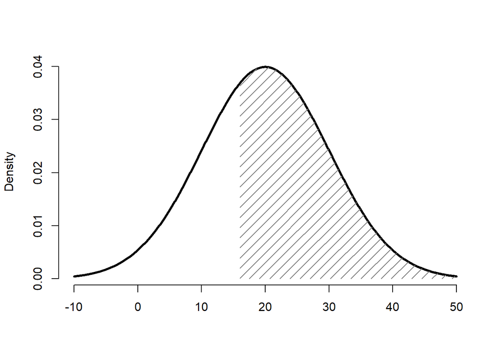

```r
area_poly <- function(cur, cutoff, side=c(1,-1), col = "grey", border=NA, ...)
{
  if (side[1]>0 )# on the right
  {
    pos <- min(which(cur$x > cutoff))
    end <- length(cur$x)
  }
  else # on the left
  {
    pos <- max(which(cur$x < cutoff))
    end <- 1
  }
  polygon(x=c(cur$x[end:pos], cur$x[pos], cur$x[end]),
          y=c(cur$y[end:pos], 0, 0), col=col, border=border, ...)
}

# Assign the curve cc (here, we don't yet standardize)
cc <- curve(dnorm(x, mean = 20, sd = 10), from = -10, to = 50, n = 1000, lwd = 3, xlab = "", ylab = "Density", frame = F)
area_poly(cc, cutoff = 16, side = 1, col = "grey50", density = 10)
```

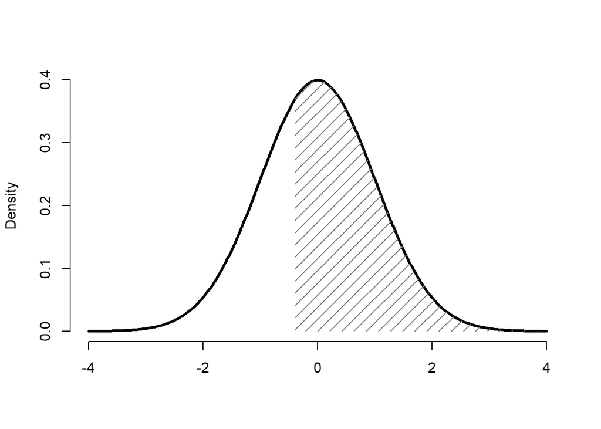

```r
# What if we standardize?
cc <- curve(dnorm(x, mean = 0, sd = 1), from = -4, to = 4, n = 1000, lwd = 3, xlab = "", ylab = "Density", frame = F)
area_poly(cc, cutoff = -.4, side = 1, col = "grey50", density = 10)
```

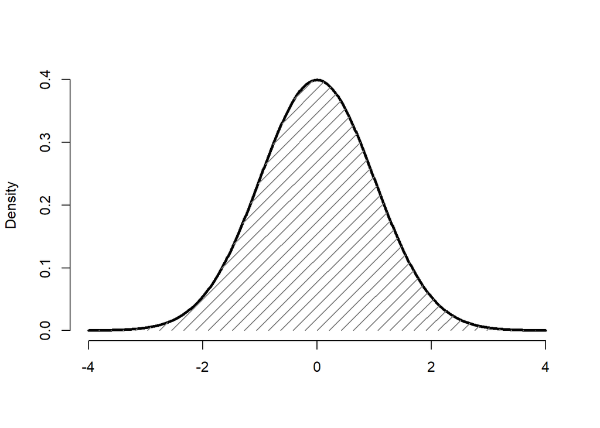

```r
# But we haven't yet adjusted for standard error!
cc <- curve(dnorm(x, mean = 0, sd = 1), from = -4, to = 4, n = 1000, lwd = 3, xlab = "", ylab = "Density", frame = F)
area_poly(cc, cutoff = -.4*sqrt(100), side = 1, col = "grey50", density = 10)
```

Specifically, we have to decide if we want a one-sided or a two-sided test.

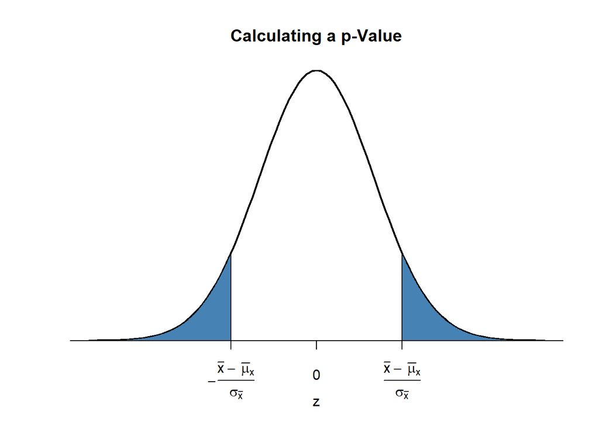

```r
# What about a two-sided test?
# plot the standard normal density on the interval [-4,4]
curve(dnorm(x),
      xlim = c(-4, 4),
      main = 'Calculating a p-Value',
      yaxs = 'i',
      xlab = 'z',
      ylab = '',
      lwd = 2,
      axes = 'F')

# add x-axis
axis(1,
     at = c(-1.5, 0, 1.5),
     padj = 0.75,
     labels = c(expression(-frac(bar(x)~-~bar(mu)[x,0], sigma[bar(x)])),
                0,
                expression(frac(bar(x)~-~bar(mu)[x,0], sigma[bar(x)]))))

# shade p-value/2 region in left tail
polygon(x = c(-6, seq(-6, -1.5, 0.01), -1.5),
        y = c(0, dnorm(seq(-6, -1.5, 0.01)),0),
        col = 'steelblue')

# shade p-value/2 region in right tail
polygon(x = c(1.5, seq(1.5, 6, 0.01), 6),
        y = c(0, dnorm(seq(1.5, 6, 0.01)), 0),
        col = 'steelblue')
```

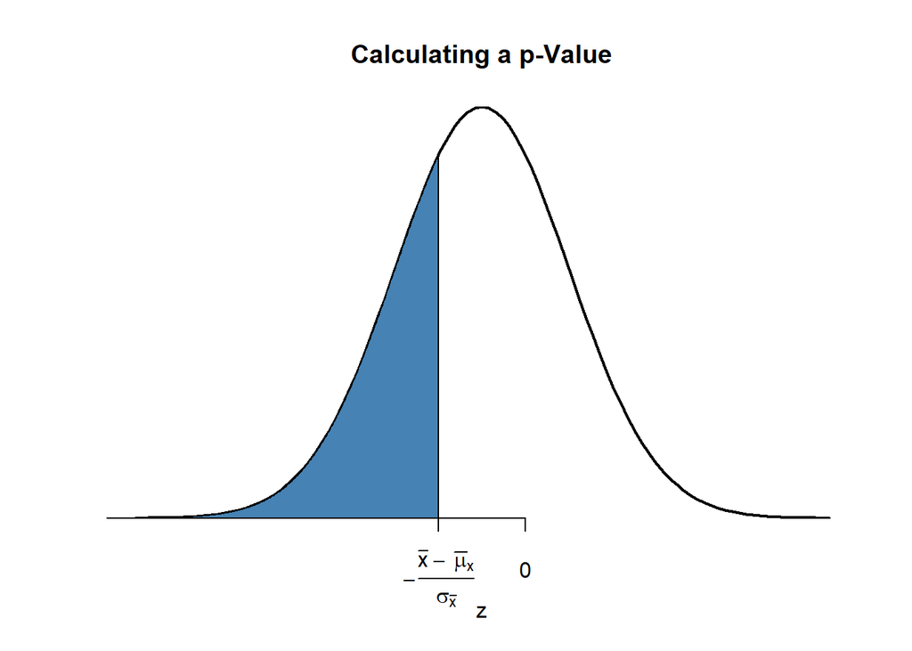

```r
# What about a ONE-sided test?
# plot the standard normal density on the interval [-4,4]
curve(dnorm(x),
      xlim = c(-4, 4),
      main = 'Calculating a p-Value',
      yaxs = 'i',
      xlab = 'z',
      ylab = '',
      lwd = 2,
      axes = 'F')

# add x-axis
axis(1,
     at = c(-.5, 0.5),
     padj = 0.75,
     labels = c(expression(-frac(bar(x)~-~bar(mu)[x,0], sigma[bar(x)])),
                0))

# shade p-value region all in left tail
polygon(x = c(-6, seq(-6, -.5, 0.01), -.5),
        y = c(0, dnorm(seq(-6, -.5, 0.01)),0),
        col = 'steelblue')
```

### Why can we use the CLT here?

The Central Limit Theorem (CLT) states that the sampling distribution of the sample mean is approximately normally distributed, regardless of the distribution of the underlying population, as long as the sample size is sufficiently large.

Importantly, the test statistic here also follows a standard normal as the sample size increases. We can show this through simulating.

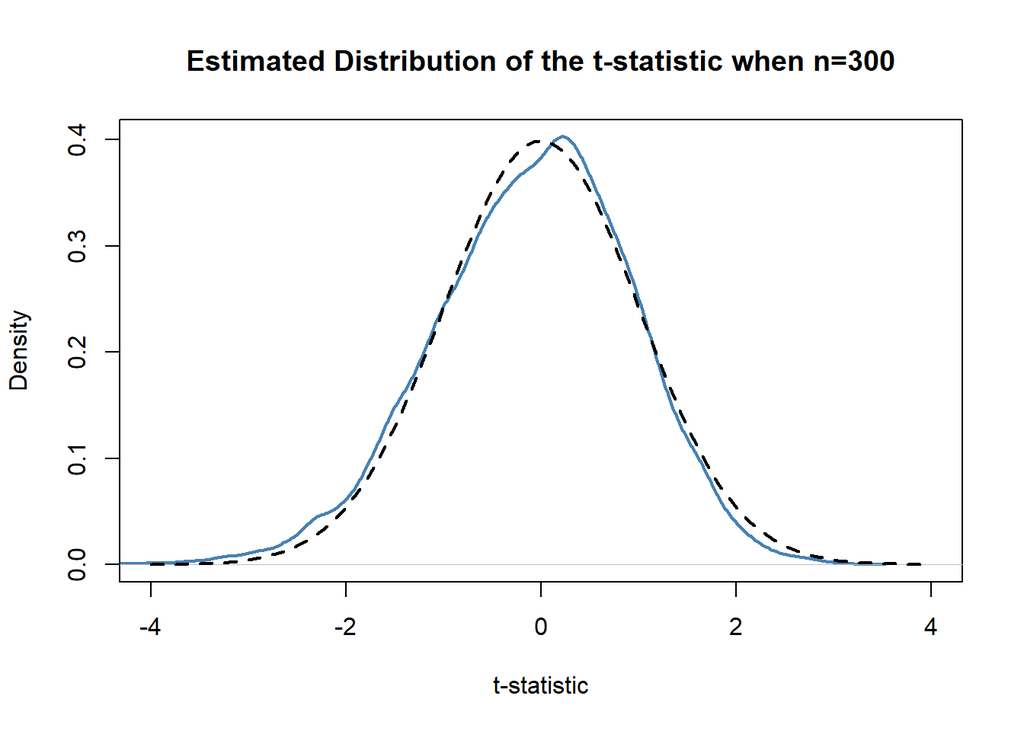

```r
# prepare empty vector for t-statistics
tstatistics <- numeric(10000)

# set sample size
n <- 300 # play around with this parameter

# simulate 10000 t-statistics
for (i in 1:10000) {

  s <- sample(0:1,
              size = n,
              prob = c(0.9, 0.1),
              replace = T)

  tstatistics[i] <- (mean(s)-0.1)/sqrt(var(s)/n)

}

# plot density and compare to N(0,1) density
plot(density(tstatistics),
     xlab = 't-statistic',
     main = 'Estimated Distribution of the t-statistic when n=300',
     lwd = 2,
     xlim = c(-4, 4),
     col = 'steelblue')

# N(0,1) density (dashed)
curve(dnorm(x),
      add = T,
      lty = 2,
      lwd = 2) # so think carefully -- what is the distribution we're showing here?
```

### How does sample size influence testing outcomes?

Finally, let’s use the example in the slides about tipping to explore the effect of limited/expanded sample sizes on testing outcomes

```r
# set seed for reproducibility
set.seed(0813)

# sample data that has 16 observations with mean 12 and var 23
tip_data <- data.frame(rnorm(16, mean = 12, sd = sqrt(23)))
names(tip_data) <- "tips"

# can we reject the null hypothesis of mean = 15 with 99% confidence?
t.test(tip_data, mu = 15, conf.level = 0.99)
```

```
##
##  One Sample t-test
##
## data:  tip_data
## t = -1.903, df = 15, p-value = 0.07642
## alternative hypothesis: true mean is not equal to 15
## 99 percent confidence interval:
##   9.737423 16.132612
## sample estimates:
## mean of x
##  12.93502
```

```r
confint(lm(tips~1,tip_data), level=0.99) # 99% confidence interval for tip_data
```

```
##                0.5 %   99.5 %
## (Intercept) 9.737423 16.13261
```

```r
# Okay, suppose that we had a larger sample size of n=100
tip_data <- data.frame(rnorm(100, mean = 12, sd = sqrt(23)))
names(tip_data) <- "tips"
t.test(tip_data, mu = 15, conf.level = 0.99)
```

```
##
##  One Sample t-test
##
## data:  tip_data
## t = -5.7814, df = 99, p-value = 8.641e-08
## alternative hypothesis: true mean is not equal to 15
## 99 percent confidence interval:
##  11.00086 13.49934
## sample estimates:
## mean of x
##   12.2501
```

```r
confint(lm(tips~1,tip_data), level=0.99)
```

```
##                0.5 %   99.5 %
## (Intercept) 11.00086 13.49934
```

```r
# What if variance changed too?
tip_data <- data.frame(rnorm(100, mean = 12, sd = sqrt(100)))
names(tip_data) <- "tips"
t.test(tip_data, mu = 15, conf.level = 0.99)
```

```
##
##  One Sample t-test
##
## data:  tip_data
## t = -2.6965, df = 99, p-value = 0.008237
## alternative hypothesis: true mean is not equal to 15
## 99 percent confidence interval:
##   9.799713 14.931529
## sample estimates:
## mean of x
##  12.36562
```

```r
confint(lm(tips~1,tip_data), level=0.99)
```

```
##                0.5 %   99.5 %
## (Intercept) 9.799713 14.93153
```

### Tests for proportions

Finally, let’s implement a test for proportions using the wagepan dataset.

```r
# We will test whether the fraction of unionized workers is different from 1980 to 1987
summary(mydata[which(mydata$year==1980),]$union)
```

```
##    Min. 1st Qu.  Median    Mean 3rd Qu.    Max.
##  0.0000  0.0000  0.0000  0.2514  1.0000  1.0000
```

```r
summary(mydata[which(mydata$year==1987),]$union) # do we think it will be?
```

```
##    Min. 1st Qu.  Median    Mean 3rd Qu.    Max.
##  0.0000  0.0000  0.0000  0.2624  1.0000  1.0000
```

```r
# To test this, let's trim the data
testdata <- mydata %>% filter(year %in% c(1980, 1987)) %>% select(union, year)
t.test(testdata$union ~ testdata$year, var.equal = F, conf.level = 0.95)
```

```
##
##  Welch Two Sample t-test
##
## data:  testdata$union by testdata$year
## t = -0.4156, df = 1087.8, p-value = 0.6778
## alternative hypothesis: true difference in means between group 1980 and group 1987 is not equal to 0
## 95 percent confidence interval:
##  -0.06298575  0.04096740
## sample estimates:
## mean in group 1980 mean in group 1987
##          0.2513761          0.2623853
```

## P-values

Let’s go back to the example from last time about tipping and think about the p-values here.

```r
# set seed for reproducibility
set.seed(0813)

# sample data that has 16 observations with mean 12 and var 23
tip_data <- data.frame(rnorm(16, mean = 12, sd = sqrt(23)))
names(tip_data) <- "tips"

# can we reject the null hypothesis of mean = 15 with 99% confidence?
t.test(tip_data, mu = 15, conf.level = 0.99)
```

```
##
##  One Sample t-test
##
## data:  tip_data
## t = -1.903, df = 15, p-value = 0.07642
## alternative hypothesis: true mean is not equal to 15
## 99 percent confidence interval:
##   9.737423 16.132612
## sample estimates:
## mean of x
##  12.93502
```

```r
confint(lm(tips~1,tip_data), level=0.99) # 99% confidence interval for tip_data
```

```
##                0.5 %   99.5 %
## (Intercept) 9.737423 16.13261
```

```r
# Okay, suppose that we had a larger sample size of n=100
tip_data <- data.frame(rnorm(100, mean = 12, sd = sqrt(23)))
names(tip_data) <- "tips"
t.test(tip_data, mu = 15, conf.level = 0.99)
```

```
##
##  One Sample t-test
##
## data:  tip_data
## t = -5.7814, df = 99, p-value = 8.641e-08
## alternative hypothesis: true mean is not equal to 15
## 99 percent confidence interval:
##  11.00086 13.49934
## sample estimates:
## mean of x
##   12.2501
```

```r
confint(lm(tips~1,tip_data), level=0.99)
```

```
##                0.5 %   99.5 %
## (Intercept) 11.00086 13.49934
```

```r
# What if variance changed too?
tip_data <- data.frame(rnorm(100, mean = 12, sd = sqrt(100)))
names(tip_data) <- "tips"
t.test(tip_data, mu = 15, conf.level = 0.99)
```

```
##
##  One Sample t-test
##
## data:  tip_data
## t = -2.6965, df = 99, p-value = 0.008237
## alternative hypothesis: true mean is not equal to 15
## 99 percent confidence interval:
##   9.799713 14.931529
## sample estimates:
## mean of x
##  12.36562
```

```r
confint(lm(tips~1,tip_data), level=0.99)
```

```
##                0.5 %   99.5 %
## (Intercept) 9.799713 14.93153
```

### Distributions of P-values

We can show these simulations directly in R.

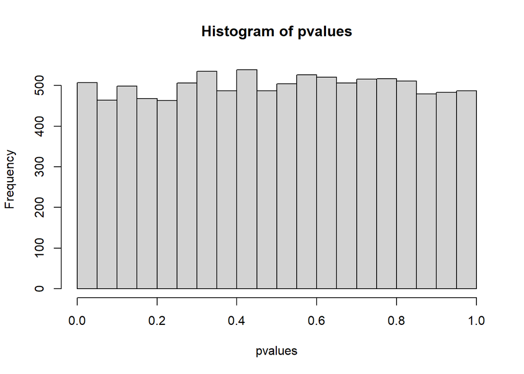

```r
# The null hypothesis is that the average is equal to 0
# We will simulate 10000 p-values under the null hypothesis
pvalues <- numeric(10000)
for (i in 1:10000) {
  s <- rnorm(100,mean=0,sd=100)
  pvalues[i] <- t.test(s, mu = 0)$p.value
}
hist(pvalues)
```

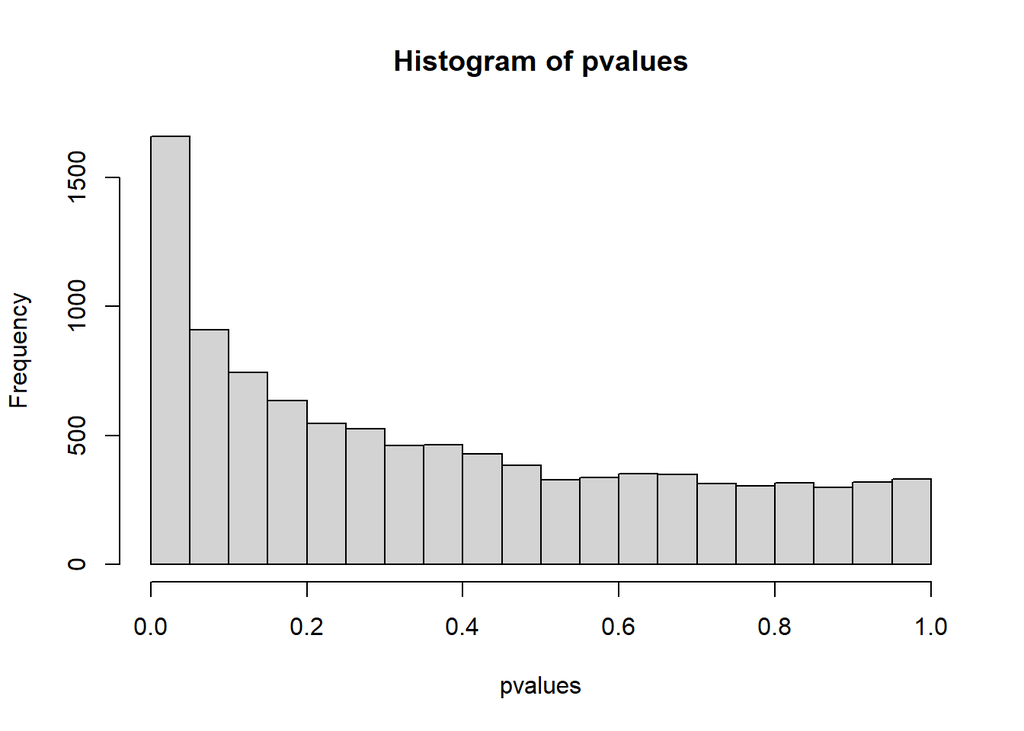

```r
# The null hypothesis is that the average is equal to 0
# We will simulate 10000 p-values under a slightly false null hypothesis
pvalues <- numeric(10000)
for (i in 1:10000) {
  s <- rnorm(100,mean=10,sd=100)
  pvalues[i] <- t.test(s, mu = 0)$p.value
}
hist(pvalues)
```

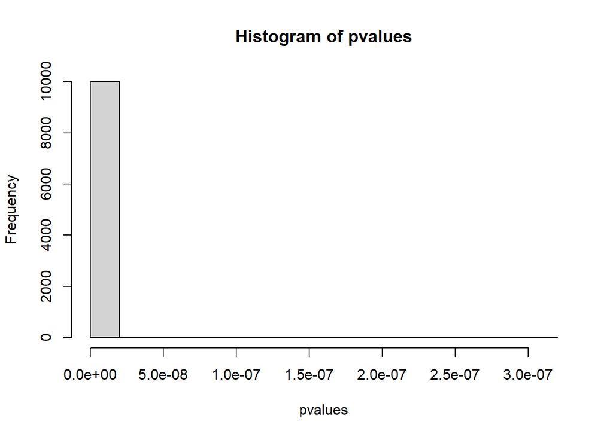

```r
# We will simulate 10000 p-values under a wildly false null hypothesis
pvalues <- numeric(10000)
for (i in 1:10000) {
  s <- rnorm(100,mean=100,sd=100)
  pvalues[i] <- t.test(s, mu = 0)$p.value
}
hist(pvalues)
```